# Diabetes & Heart Disease EDA

```python
import pandas as pd
import numpy as np
import matplotlib.pyplot as plt
import seaborn as sns
```

<h1 id="Healthcare-Data-Analysis-Report">Healthcare Data Analysis Report</h1><p>This report analyzes Diabetes and Heart Disease datasets.</p>

```python
heart = pd.read_csv("heart.csv")
diabetes = pd.read_csv("diabetes_prediction_dataset.csv")
heart.shape
```

```
(1025, 14)
```

<h2 id="1.-Diabetes-Analysis">1. Diabetes Analysis</h2>

```python
diabetes.head()
diabetes.columns
```

```
Index(['gender', 'age', 'hypertension', 'heart_disease', 'smoking_history',
       'bmi', 'HbA1c_level', 'blood_glucose_level', 'diabetes'],
      dtype='str')
```

<h3 id="1.1-Missing-Values">1.1 Missing Values</h3>

```python
diabetes.isna().sum()
```

```
gender                 0
age                    0
hypertension           0
heart_disease          0
smoking_history        0
bmi                    0
HbA1c_level            0
blood_glucose_level    0
diabetes               0
dtype: int64
```

<p>No missing values found in the dataset.</p>

<h3 id="1.2-Diabetic-Patients-Count">1.2 Diabetic Patients Count</h3>

```python
target_pateintD = diabetes[diabetes['diabetes'] == 1].value_counts()
print(target_pateintD)
# target_pateintD.shape
```

```
gender  age   hypertension  heart_disease  smoking_history  bmi    HbA1c_level  blood_glucose_level  diabetes
Female  80.0  0             0              never            27.32  8.2          280                  1           3
        53.0  0             0              never            27.32  6.6          155                  1           2
                                                                   9.0          160                  1           2
Male    38.0  0             0              No Info          31.85  5.7          220                  1           2
        60.0  0             0              never            27.32  6.5          300                  1           2
                                                                                                                ..
Female  65.0  1             1              never            33.55  8.2          140                  1           1
Male    55.0  0             1              former           30.42  6.2          300                  1           1
Female  61.0  0             0              No Info          34.45  6.5          280                  1           1
        58.0  1             0              never            38.31  7.0          200                  1           1
        61.0  0             0              current          30.11  6.2          240                  1           1
Name: count, Length: 8482, dtype: int64
```

<h3 id="1.3-Key-Statistics">1.3 Key Statistics</h3>

```python
print(f"Max age of person in diabetes dataset is {np.max(diabetes['age'])}")
print(f"Avg targets in diabetes dataset is {round(np.mean(diabetes['diabetes']),2)}")
print(f"Min blood_glucose_level in heart dataset is {np.min(diabetes['blood_glucose_level'])}")
targeted = np.mean(diabetes['diabetes'])*100
print(f"Percentage of diabetes patient is {round(targeted,2)}%")
```

```
Max age of person in diabetes dataset is 80.0
Avg targets in diabetes dataset is 0.08
Min blood_glucose_level in heart dataset is 80
Percentage of diabetes patient is 8.5%
```

<h3 id="1.4-Age-Distribution-by-Diabetes-Status">1.4 Age Distribution by Diabetes Status</h3>

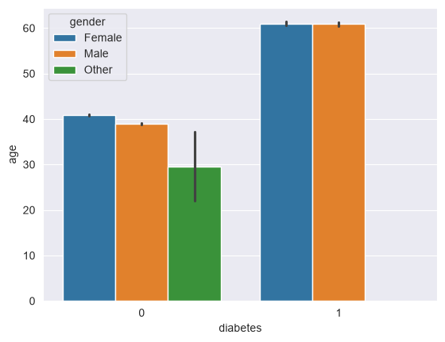

```python
sns.barplot(data=diabetes, x="diabetes", y="age",hue='gender')
```

<p>Diabetic patients tend to be older on average.</p>

```python
### 1.5 Age Distribution by Gender
```

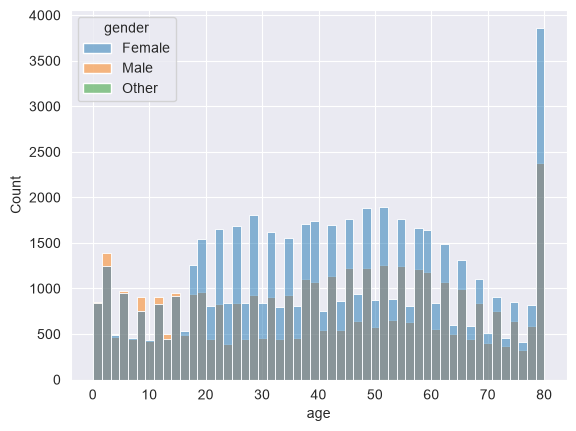

```python
sns.histplot(data = diabetes, x="age", hue='gender')
```

<h3 id="1.6-Correlation-Heatmap">1.6 Correlation Heatmap</h3>

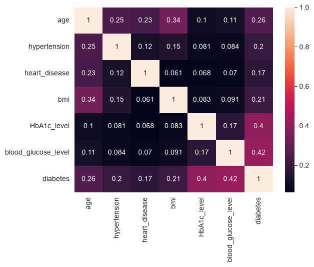

```python
sns.heatmap(diabetes.corr(numeric_only=True) , annot=True)
```

<p>Blood glucose level and HbA1c show strong correlation with diabetes.</p>

<h3 id="1.7-BMI-Distribution-by-Gender">1.7 BMI Distribution by Gender</h3>

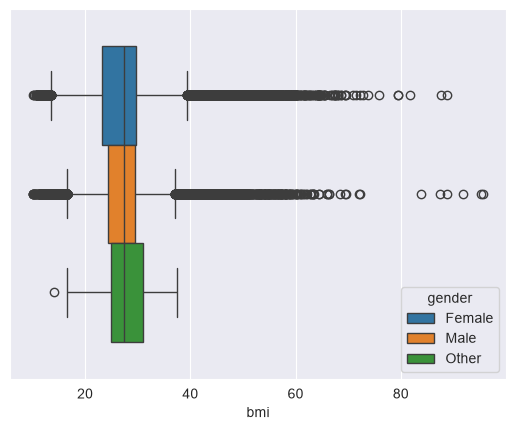

```python
sns.boxplot(data=diabetes,x=diabetes['bmi'],hue='gender')
```

<h3 id="1.8-Average-Glucose-Level">1.8 Average Glucose Level</h3>

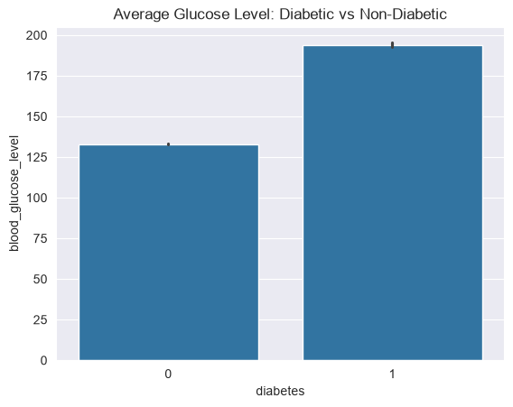

```python
sns.barplot(data=diabetes, x="diabetes", y="blood_glucose_level")
plt.title("Average Glucose Level: Diabetic vs Non-Diabetic")
plt.show()
```

<p>Diabetic patients have significantly higher blood glucose levels.</p>

<h2 id="1.-HeartPatient-Analysis">1. HeartPatient Analysis</h2><p>This section analyzes the heart disease dataset to explore patterns among patients.</p>

```python
heart.head()
```

| 52 | 1 | 0 | 125 | 212 | 0 | 1 | 168 | 0 | 1.0 | 2 | 2 | 3 | 0 |
| --- | --- | --- | --- | --- | --- | --- | --- | --- | --- | --- | --- | --- | --- |
| 53 | 1 | 0 | 140 | 203 | 1 | 0 | 155 | 1 | 3.1 | 0 | 0 | 3 | 0 |
| 70 | 1 | 0 | 145 | 174 | 0 | 1 | 125 | 1 | 2.6 | 0 | 0 | 3 | 0 |
| 61 | 1 | 0 | 148 | 203 | 0 | 1 | 161 | 0 | 0.0 | 2 | 1 | 3 | 0 |
| 62 | 0 | 0 | 138 | 294 | 1 | 1 | 106 | 0 | 1.9 | 1 | 3 | 2 | 0 |

<h3 id="2.1-Missing-Values">2.1 Missing Values</h3>

```python
heart.isna().sum()
```

```
age         0
sex         0
cp          0
trestbps    0
chol        0
fbs         0
restecg     0
thalach     0
exang       0
oldpeak     0
slope       0
ca          0
thal        0
target      0
dtype: int64
```

<p>No missing values found in the heart disease dataset.</p>

<h3 id="2.2-Heart-Disease-Patients-Count">2.2 Heart Disease Patients Count</h3>

```python
target_pateint = heart[heart['target'] == 1].value_counts()
print(target_pateint)
```

```
age  sex  cp  trestbps  chol  fbs  restecg  thalach  exang  oldpeak  slope  ca  thal  target
38   1    2   138       175   0    1        173      0      0.0      2      4   2     1         8
71   0    0   112       149   0    1        125      0      1.6      1      0   2     1         4
58   1    2   140       211   1    0        165      0      0.0      2      0   2     1         4
54   1    2   120       258   0    0        147      0      0.4      1      0   3     1         4
55   0    1   132       342   0    1        166      0      1.2      2      0   2     1         4
                                                                                               ..
              135       250   0    0        161      0      1.4      1      0   2     1         3
60   0    2   120       178   1    1        96       0      0.0      2      0   2     1         3
52   1    0   108       233   1    1        147      0      0.1      2      3   3     1         3
68   0    2   120       211   0    0        115      0      1.5      1      0   2     1         3
44   0    2   108       141   0    1        175      0      0.6      1      0   2     1         3
Name: count, Length: 164, dtype: int64
```

<h3 id="2.3-Patients-Grouped-by-Age,-Gender-and-Target">2.3 Patients Grouped by Age, Gender and Target</h3>

```python
print(heart.groupby(['age','sex','target']).sum())
```

```
                cp  trestbps  chol  fbs  restecg  thalach  exang  oldpeak  \
age sex target
29  1   1        4       520   816    0        0      808      0      0.0
34  0   1        3       354   630    0        3      576      0      2.1
    1   1        9       354   546    0        0      522      0      0.0
35  0   1        0       552   732    0        4      728      0      5.6
    1   0        0       858  1638    0        4      988      7      6.4
...             ..       ...   ...  ...      ...      ...    ...      ...
70  1   1        3       468   735    0        0      429      0      0.0
71  0   1       11      1368  2562    4        7     1506      0      7.6
74  0   1        3       360   807    0        0      363      3      0.6
76  0   1        6       420   591    0        6      348      0      3.3
77  1   0        0       375   912    0        0      486      3      0.0

                slope  ca  thal
age sex target
29  1   1           8   0     8
34  0   1           6   0     6
    1   1           6   0     6
35  0   1           8   0     8
    1   0          10   0    21
...               ...  ..   ...
70  1   1           6   0     6
71  0   1          18  10    22
74  0   1           6   3     6
76  0   1           3   0     6
77  1   0           6   9     6

[116 rows x 11 columns]
```

<h3 id="2.4-Key-Statistics">2.4 Key Statistics</h3>

```python
print(f"Max age of person in heart dataset is {np.max(heart['age'])}")
print(f"Avg targets in heart dataset is {round(np.mean(heart['target']),2)}")
print(f"Min Cholestrol in heart dataset is {np.min(heart['chol'])}")
targeted = np.mean(heart['target'])*100
print(f"Percentage of heart patient is {round(targeted,2)}%")
```

```
Max age of person in heart dataset is 77
Avg targets in heart dataset is 0.51
Min Cholestrol in heart dataset is 126
Percentage of heart patient is 51.32%
```

<h3 id="2.5-Gender-Distribution">2.5 Gender Distribution</h3>

```python
heart['sex'].value_counts()
```

```
sex
1    713
0    312
Name: count, dtype: int64
```

<h3 id="2.6-Male-vs-Female-Pie-Chart">2.6 Male vs Female Pie Chart</h3>

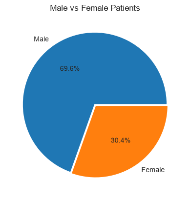

```python
gender_counts = heart['sex'].value_counts()
plt.pie(gender_counts, labels=['Male', 'Female'], autopct='%0.1f%%', explode=[0.01, 0.01])
plt.title("Male vs Female Patients")
plt.show()
```

<p>Dataset contains more male patients than female patients.</p>

<h3 id="2.7-Heart-Disease-vs-No-Heart-Disease">2.7 Heart Disease vs No Heart Disease</h3>

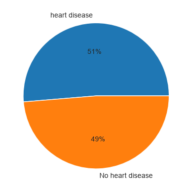

```python
plt.pie(heart['target'].value_counts(),labels=['heart disease','No heart disease'],autopct='%1.0f%%')
```

<p>Around 51% patients have heart disease in this dataset.</p>

<h3 id="2.8-Age-Distribution-by-Gender">2.8 Age Distribution by Gender</h3>

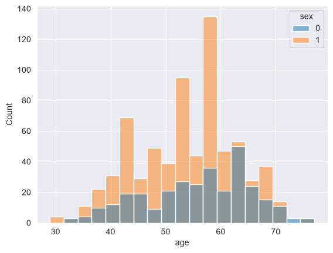

```python
sns.histplot(data = heart, x="age", hue='sex')
```

<h3 id="2.9-Heart-Disease-by-Gender">2.9 Heart Disease by Gender</h3>

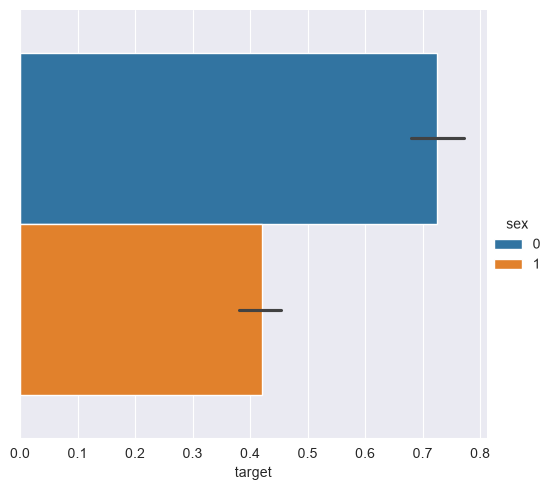

```python
sns.catplot(data = heart, x='target',hue = 'sex', kind = 'bar')
```

<h3 id="2.10-Chest-Pain-Types">2.10 Chest Pain Types</h3>

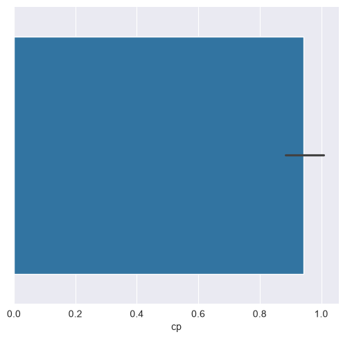

```python
sns.catplot(data = heart, x = 'cp' , kind = 'bar')
```

<h3 id="2.11-Correlation-Heatmap">2.11 Correlation Heatmap</h3>

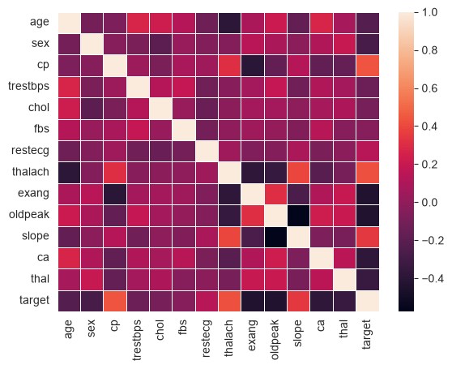

```python
sns.heatmap(heart.corr(numeric_only=True) ,linewidths=.5)
```